# Common Garden Design

## Intro

Determine randomization strategy and plant placing for 2026 Wrights Lake 2 Planting

```r
library(tidyverse)
library(googlesheets4)
library(ggforce)

is.even <- function(x) x%%2 == 0

popsheet <- "https://docs.google.com/spreadsheets/d/12E6iegjdVGfiqv1H9B_WJC0qA0_OlAdwDQrbbUI-OP8/edit?gid=852415812#gid=852415812"
```

## IMPORTANT

Snaking blocks through the beds really should be done but it is tricky to coordinate with the blocked positions from the field.

## get germination and transplant data

```r
germ_data <- read_csv("../input/WL2_2026_InitialSize_DNA_corrected_inprogress.csv") %>%
  select(Rack:Unique.ID, germ.y.n)

popinfo <- read_sheet(popsheet,
                  sheet = "Labeling-ToPrint",
                  na=c("NA", ""),
                  col_types = "c") %>%
  select(Type, pop.id:sire_mf, Rep, Unique.ID) %>%
  mutate(Unique.ID=as.numeric(Unique.ID))
popinfo_norep <- popinfo %>% select(-Rep)

transplants <- read_csv("../input/WL2_2026_Transplanting_corrected.csv") #transplant info (extra germs)
transplants_mf <- transplants %>%
  select(-rep) %>%
  mutate(germ.y.n="Y") %>%
  left_join(popinfo_norep, by=join_by(old_uniquelD == Unique.ID, pop.id)) %>%
  select(Type, pop.id, dame_mf:sire_mf, Unique.ID=new_uniquelD, Rack=new_rack, germ.y.n)

newsdls <- tibble(old_uniquelD=c(3252, 3252, 3269, 3269, 3338, 3338, 3380, 3396),
                  new_uniquelD=c(3953, 3954, 3955, 3956, 3957, 3958, 3959, 3960),
                  germ.y.n="Y") #add sdls found during size/DNA census
newsdlspops <- newsdls %>%
  left_join(popinfo_norep, by=join_by(old_uniquelD == Unique.ID)) %>%
  select(Type, pop.id, dame_mf:sire_mf, Unique.ID=new_uniquelD, germ.y.n)


germ_only <- germ_data %>%
  left_join(popinfo) %>%
  filter(!is.na(pop.id)) %>%
  bind_rows(transplants_mf) %>%
  bind_rows(newsdlspops) %>%
  rename(germinated.y.n=germ.y.n) %>%
  #remove plants that were not there during size/DNA
  filter(Unique.ID!=3038) %>%
  filter(Unique.ID!=3490) %>%
  filter(Unique.ID!=3514) %>%
  filter(Unique.ID!=3920) %>%
  filter(Unique.ID!=3815) %>%
  filter(germinated.y.n=="Y")
```

```r
germinated <- germ_only %>%
  unite("mf", dame_mf:sire_mf, remove = FALSE, na.rm = TRUE) %>%
  group_by(pop.id) %>%
  mutate(rep_for_blocking=row_number()) %>%  #add smooth rep number for block assignments
  mutate(reps=n()) #sum number of reps per pop
#605 plants germinated
names(germinated)
```

```
 [1] "Rack"             "Unique.ID"        "germinated.y.n"   "Type"
 [5] "pop.id"           "mf"               "dame_mf"          "sire_mf"
 [9] "Rep"              "rep_for_blocking" "reps"
```

```r
germinated %>% arrange(pop.id) %>% head()
```

| Rack | Unique.ID | germinated.y.n | Type | pop.id | mf | dame_mf | sire_mf | Rep | rep_for_blocking | reps |
| --- | --- | --- | --- | --- | --- | --- | --- | --- | --- | --- |
| 3 | 3489 | Y | BC2 | ((WL2 X WL1) X WL2) X WL2) | 2_28-2 | 2 | 28-2 | 6 | 1 | 5 |
| 6 | 3491 | Y | BC2 | ((WL2 X WL1) X WL2) X WL2) | 2_28-2 | 2 | 28-2 | 8 | 2 | 5 |
| 6 | 3492 | Y | BC2 | ((WL2 X WL1) X WL2) X WL2) | 2_28-2 | 2 | 28-2 | 9 | 3 | 5 |
| 6 | 3493 | Y | BC2 | ((WL2 X WL1) X WL2) X WL2) | 2_28-2 | 2 | 28-2 | 10 | 4 | 5 |
| 6 | 3499 | Y | BC2 | ((WL2 X WL1) X WL2) X WL2) | 2_28-2 | 2 | 28-2 | 16 | 5 | 5 |
| 1 | 3213 | Y | BC1 | (CC X WL2) X WL2 | 4_2A | 4 | 2A | 1 | 1 | 33 |

## assign blocks to germinated

get a histogram of rep count

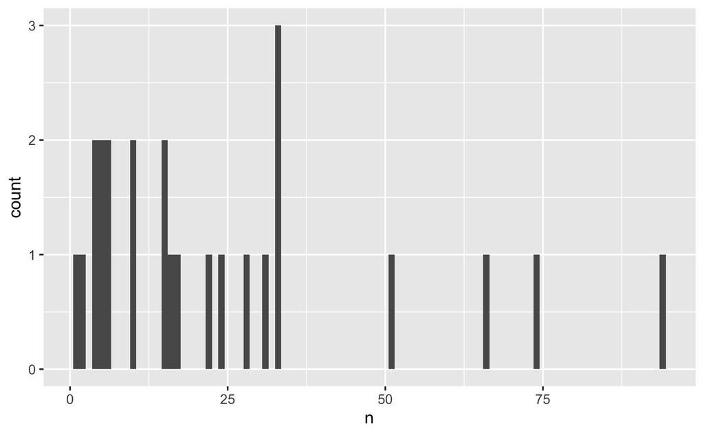

```r
germinated %>%
  group_by(pop.id) %>%
  summarize(n=n()) %>%
  ggplot(aes(x=n)) +
  geom_histogram(binwidth = 1)
```

```r
summary(germinated)
```

```
      Rack          Unique.ID    germinated.y.n         Type
 Min.   : 1.000   Min.   :3002   Length:605         Length:605
 1st Qu.: 3.000   1st Qu.:3329   Class :character   Class :character
 Median : 7.000   Median :3632   Mode  :character   Mode  :character
 Mean   : 6.636   Mean   :3569
 3rd Qu.:10.000   3rd Qu.:3807
 Max.   :11.000   Max.   :3960
 NA's   :9
    pop.id               mf              dame_mf            sire_mf
 Length:605         Length:605         Length:605         Length:605
 Class :character   Class :character   Class :character   Class :character
 Mode  :character   Mode  :character   Mode  :character   Mode  :character




     Rep            rep_for_blocking      reps
 Length:605         Min.   : 1.00    Min.   : 1.00
 Class :character   1st Qu.: 7.00    1st Qu.:24.00
 Mode  :character   Median :17.00    Median :33.00
                    Mean   :24.21    Mean   :47.43
                    3rd Qu.:34.00    3rd Qu.:74.00
                    Max.   :94.00    Max.   :94.00
```

```r
germinated %>%
  group_by(pop.id) %>%
  summarize(n=n()) %>%
  arrange(n)
```

| pop.id | n |
| --- | --- |
| (YO11 X WL2) X WL2 | 1 |
| YO11 | 2 |
| (WL2 X BH) X WL2 | 4 |
| WL1 | 4 |
| ((WL2 X WL1) X WL2) X WL2) | 5 |
| LV1 | 5 |
| (WL2 X TM2) X WL2 | 6 |
| CC | 6 |
| (WL2 X WL1) x WL2 | 10 |
| (WV X WL2) X WL2 | 10 |

[output cut: 15 more lines]

```r
germinated %>%
  group_by(pop.id) %>%
  summarize(n=n()) %>%
  summary()
```

```
    pop.id                n
 Length:25          Min.   : 1.0
 Class :character   1st Qu.: 6.0
 Mode  :character   Median :16.0
                    Mean   :24.2
                    3rd Qu.:33.0
                    Max.   :94.0
```

A bit challenging because for pops with few reps total we should be careful to distribute the pops across the blocks.  
Also different max rep sizes: ~30 for a couple BC1 (With one >90), 5 for the BC2.

Will go for 16 blocks total (that’s the median sample size)

I think one way this can work is to arrange by pops and then assign a randomized set of block labels to it.

```r
#terminology with "germ" prefix is a leftover from UCD2022 when we planted both germinated and ungerminated seed.

nblocks <- 16

germblocks <- LETTERS[1:nblocks]

germreps <- ceiling(nrow(germinated) / length(germblocks) ) # number of times we have to assign blocks

germinated$block <- rep(germblocks, length.out=nrow(germinated))

#for low rep mfs, randomize all mfs in the pop that have have < nblocks
set.seed(888)
germinated_low_extra_rep <- germinated %>%
  group_by(pop.id) %>%
  filter(reps < 16 | rep_for_blocking > 16) %>% # because nblocks represents full replication.
  #Pull pops with less than nblocks reps and pull extra reps from those with > nblocks
  group_by(pop.id) %>%
  mutate(block= {map(1:ceiling(n()/nblocks), ~ sample(germblocks)) %>% #sampling without replacement 1 block at a time helps with even distribution across blocks.
      unlist() %>% magrittr::extract(1:n())}, # clean up last rep
  ) %>%
  ungroup()

#For high rep pops, just use the sequentially assigned blocks
germinated_fullrep <- germinated %>%
  group_by(pop.id) %>%
  filter(reps >= nblocks, rep_for_blocking < nblocks+1) %>% #get those plants corresponding to full germination but not extra
  ungroup()

germinated_blocks <- bind_rows(germinated_low_extra_rep, germinated_fullrep) %>%
  arrange(pop.id)

summary(germinated_blocks)
```

```
      Rack          Unique.ID    germinated.y.n         Type
 Min.   : 1.000   Min.   :3002   Length:605         Length:605
 1st Qu.: 3.000   1st Qu.:3329   Class :character   Class :character
 Median : 7.000   Median :3632   Mode  :character   Mode  :character
 Mean   : 6.636   Mean   :3569
 3rd Qu.:10.000   3rd Qu.:3807
 Max.   :11.000   Max.   :3960
 NA's   :9
    pop.id               mf              dame_mf            sire_mf
 Length:605         Length:605         Length:605         Length:605
 Class :character   Class :character   Class :character   Class :character
 Mode  :character   Mode  :character   Mode  :character   Mode  :character




     Rep            rep_for_blocking      reps          block
 Length:605         Min.   : 1.00    Min.   : 1.00   Length:605
 Class :character   1st Qu.: 7.00    1st Qu.:24.00   Class :character
 Mode  :character   Median :17.00    Median :33.00   Mode  :character
                    Mean   :24.21    Mean   :47.43
                    3rd Qu.:34.00    3rd Qu.:74.00
                    Max.   :94.00    Max.   :94.00
```